# Reproducible Research: Peer Assessment 1

Yuva

July 7, 2016

# Reproducible Research:Peer Assessment 1

# Prepare the R environment

Throughout this report when writing code chunks in the R markdown document, always use echo = TRUE so that someone else will be able to read the code.

First, we set echo equal to TRUE and results equal to ‘hold’ as global options for this document.

```r
library(knitr)
opts_chunk$set(echo = TRUE, results = 'hold')
```

load required libraries

```r
library(data.table)
```

```r
library(ggplot2)
```

# loading the unzipped data file into R

```r
activity <- read.csv('activity.csv', header = TRUE, sep = ",",
                  colClasses=c("numeric", "character", "numeric"))
```

# preprocessing the loaded data

convert the date field to Date class and interval field to Factor class.

```r
activity$date <- as.Date(activity$date, format = "%Y-%m-%d")
activity$interval <- as.factor(activity$interval)
```

# lets check the structure of the data using str()

```r
str(activity)
```

```
## 'data.frame':    17568 obs. of  3 variables:
##  $ steps   : num  NA NA NA NA NA NA NA NA NA NA ...
##  $ date    : Date, format: "2012-10-01" "2012-10-01" ...
##  $ interval: Factor w/ 288 levels "0","5","10","15",..: 1 2 3 4 5 6 7 8 9 10 ...
```

# Mean total number of steps per day?

calculation total steps per day

```r
steps_per_day <-aggregate(steps ~ date, activity, sum)
colnames(steps_per_day) <- c("date","steps")
head(steps_per_day)
```

```
##         date steps
## 1 2012-10-02   126
## 2 2012-10-03 11352
## 3 2012-10-04 12116
## 4 2012-10-05 13294
## 5 2012-10-06 15420
## 6 2012-10-07 11015
```

1. Now we make a histogram of the total number of steps taken per day, plotted with appropriate bin interval.

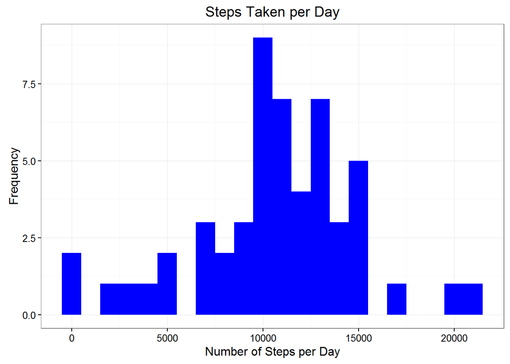

```r
ggplot(steps_per_day, aes(x = steps)) +
       geom_histogram(fill = "blue", binwidth = 1000) +
        labs(title="Steps Taken per Day",
             x = "Number of Steps per Day", y = "Frequency") + theme_bw()
```

# Mean and median of total number of steps per day

```r
mean_steps <- mean(steps_per_day$steps, na.rm = TRUE)
median_steps <- median(steps_per_day$steps, na.rm=TRUE)
mean_steps
median_steps
```

```
## [1] 10766.19
## [1] 10765
```

mean steps per day = 10766.19 median steps per day = 10765

# What is the average daily activity pattern?

We calculate the aggregation of steps by intervals of 5-minutes and convert the intervals as integers and save them in a data frame called steps_per_interval.

```r
steps_per_interval <- aggregate(activity$steps,
                                by = list(interval = activity$interval),
                                FUN=mean, na.rm=TRUE)
## lets convert it to interger which will make the plot easy

steps_per_interval$interval <-
        as.integer(levels(steps_per_interval$interval)[steps_per_interval$interval])
colnames(steps_per_interval) <- c("interval", "steps")
```

We make a plot with the time series of the average number of steps taken (averaged across all days) versus the 5-minute intervals

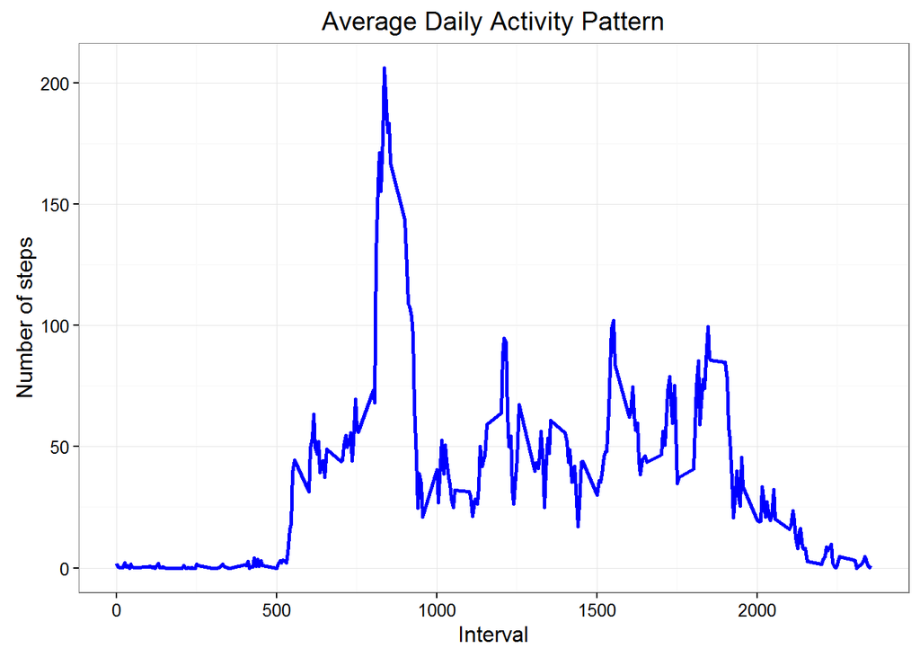

```r
ggplot(steps_per_interval, aes(x=interval, y=steps)) +
        geom_line(color="blue", size=1) +
        labs(title="Average Daily Activity Pattern", x="Interval", y="Number of steps") +
        theme_bw()
```

we find the 5-minute interval with the containing the maximum number of steps

```r
steps_per_interval[which.max(
        steps_per_interval$steps),]
```

```
##     interval    steps
## 104      835 206.1698
```

# Imputting missing values

total number of missing values in the dataset

```r
sum(is.na(activity$steps))
```

```
## [1] 2304
```

Total number of missing values = 2304

# Filling out missing value

lets fill the missing values with the mean create a function na_fill(data, pervalue) which the data arguement is the activity data frame and pervalue arguement is the steps_per_interval data frame

```r
na_fill <- function(data, pervalue) {
        na_index <- which(is.na(data$steps))
        na_replace <- unlist(lapply(na_index, FUN=function(idx){
                interval = data[idx,]$interval
                pervalue[pervalue$interval == interval,]$steps
        }))
        fill_steps <- data$steps
        fill_steps[na_index] <- na_replace
        fill_steps
}

activity_fill <- data.frame(
        steps = na_fill(activity, steps_per_interval),
        date = activity$date,
        interval = activity$interval)
str(activity_fill)
```

```
## 'data.frame':    17568 obs. of  3 variables:
##  $ steps   : num  1.717 0.3396 0.1321 0.1509 0.0755 ...
##  $ date    : Date, format: "2012-10-01" "2012-10-01" ...
##  $ interval: Factor w/ 288 levels "0","5","10","15",..: 1 2 3 4 5 6 7 8 9 10 ...
```

lets check whether there is any missing value in the activity_fill data frame

```r
sum(is.na(activity_fill$steps))
```

```
## [1] 0
```

Output is zero means there is no missing value in the dataframe

# Histogram for the total number of steps taken per day

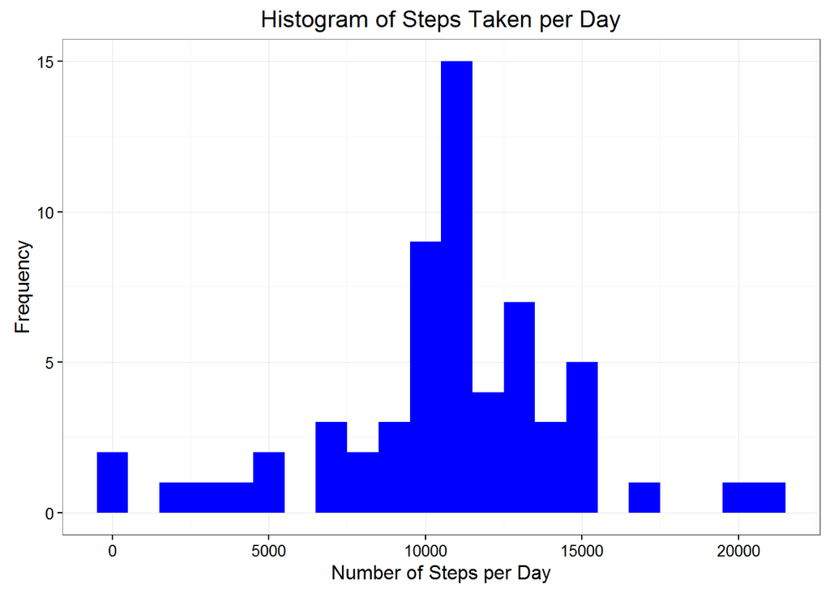

```r
fill_steps_per_day <- aggregate(steps ~ date, activity_fill, sum)
colnames(fill_steps_per_day) <- c("date","steps")
ggplot(fill_steps_per_day, aes(x = steps)) +
       geom_histogram(fill = "blue", binwidth = 1000) +
        labs(title="Histogram of Steps Taken per Day",
             x = "Number of Steps per Day", y = "Frequency") + theme_bw()
```

# Calculate and report the mean and median total number of steps taken per day

```r
mean(fill_steps_per_day$steps)
median(fill_steps_per_day$steps)
```

```
## [1] 10766.19
## [1] 10766.19
```

The mean and median of the data set is surprisingly equal to 10766.19. There is not much of a difference between the original data and the data set filled with the mean for the missing value

# Before filling the data

Mean = 10766.19,

Median =10765

# After filling the data

Mean = 10766.19,

Median = 10766.19

# What is the impact of imputing missing data on the estimates of the total daily number of steps?

# Are there differences in activity patterns between weekdays and weekends?

We do this comparison with the table with filled-in missing values. 1. Augment the table with a column that indicates the day of the week 2. Subset the table into two parts - weekends (Saturday and Sunday) and weekdays (Monday through Friday). 3. Tabulate the average steps per interval for each data set. 4. Plot the two data sets side by side for comparison.

```r
weekdays_steps <- function(data) {
    weekdays_steps <- aggregate(data$steps, by=list(interval = data$interval),
                          FUN=mean, na.rm=T)
    # convert to integers for plotting
    weekdays_steps$interval <-
            as.integer(levels(weekdays_steps$interval)[weekdays_steps$interval])
    colnames(weekdays_steps) <- c("interval", "steps")
    weekdays_steps
}

data_by_weekdays <- function(data) {
    data$weekday <-
            as.factor(weekdays(data$date)) # weekdays
    weekend_data <- subset(data, weekday %in% c("Saturday","Sunday"))
    weekday_data <- subset(data, !weekday %in% c("Saturday","Sunday"))

    weekend_steps <- weekdays_steps(weekend_data)
    weekday_steps <- weekdays_steps(weekday_data)

    weekend_steps$dayofweek <- rep("weekend", nrow(weekend_steps))
    weekday_steps$dayofweek <- rep("weekday", nrow(weekday_steps))

    data_by_weekdays <- rbind(weekend_steps, weekday_steps)
    data_by_weekdays$dayofweek <- as.factor(data_by_weekdays$dayofweek)
    data_by_weekdays
}

data_weekdays <- data_by_weekdays(activity_fill)
```

panel plot comparing the average number of steps taken per 5-minute interval across weekdays and weekend

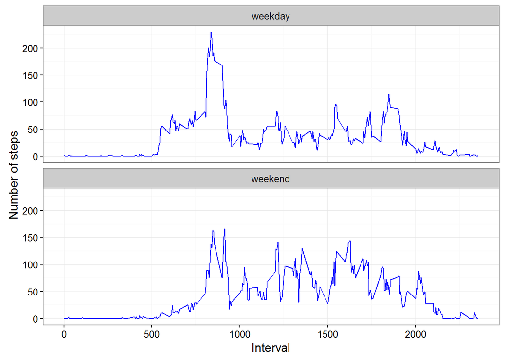

```r
ggplot(data_weekdays, aes(x=interval, y=steps)) +
        geom_line(color="blue") +
        facet_wrap(~ dayofweek, nrow=2, ncol=1) +
        labs(x="Interval", y="Number of steps") +
        theme_bw()
```